# Envejecimiento en la Argentina: brechas de género en la edad de retiro del mercado de trabajo. Años 2018-2023.

## Envejecimiento en la Argentina: brechas de género en la edad de retiro del mercado de trabajo. Años 2018-2023.

Gomez Vargas, Andrea | Iummato, Luciana | Pesce Andrea Gisele

Indicadores Socioeconómicos  
Maestría en Generación y Análisis de Información Estadística  
UNTREF

21 de octubre de 2024

## Planteamiento del problema

- Envejecimiento poblacional y feminización de la vejez
- Aumento de la pobreza, pérdida de seguridad económica en la vejez
- Desigualdades en la inserción laboral entre varones y mujeres
- > Propósito: explorar las brechas de género en la vejez en relación con la seguridad económica a través de: composición de los hogares y distribución de las tareas de cuidado, cobertura previsional, cobertura de salud, adhesión a moratoria e ingresos.

## Estado actual del conocimiento sobre el tema

Factores que influyen en la seguridad económica en la vejez<sup>1</sup>

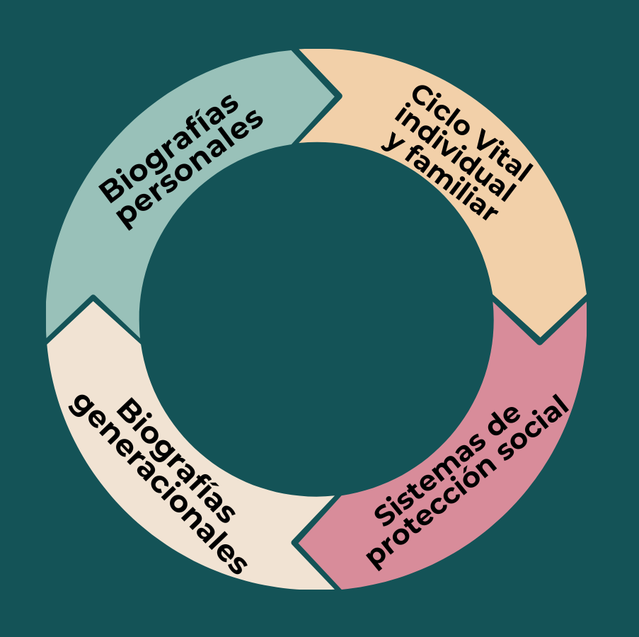

Fuentes de la seguridad económica en la vejez

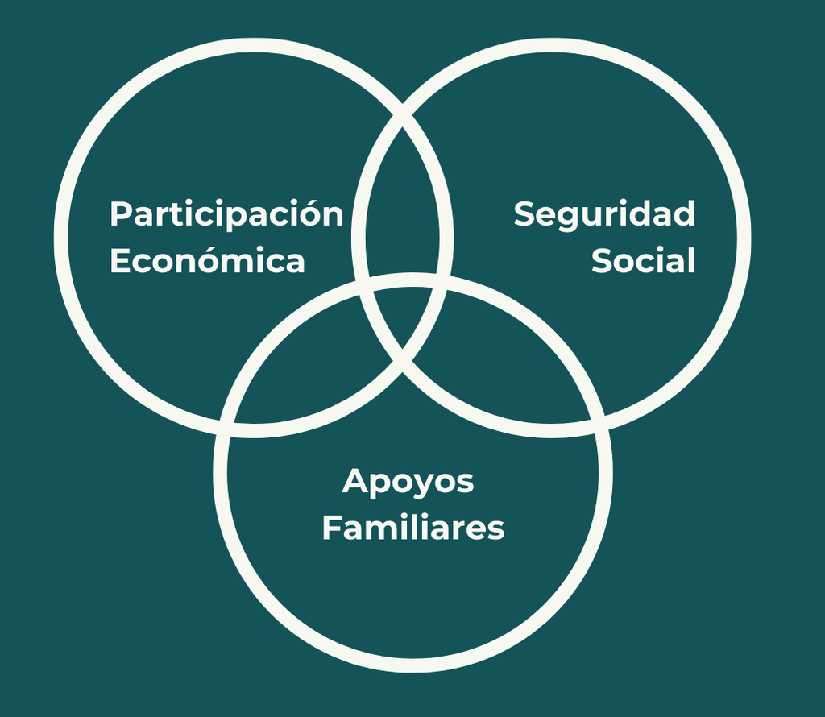

[^1]: fuente: Huenchuan S. & Guzmán, J.M. (2006) Seguridad Económica y Pobreza en la Vejez. CEPAL - CELADE.

## Objetivos

### Objetivo general:

- Analizar las brechas de género en la seguridad económica en la vejez entre 2018 y 2023, en la población argentina.

### Objetivos específicos:

- Caracterizar la composición de los hogares y distribución de las tareas de cuidado, la cobertura previsional, la cobertura de salud, la adhesión a moratoria y los ingresos en las mujeres de 60 años y más, y en los varones de 65 años y más, en el período 2018-2023.
- Analizar las brechas de género de acuerdo a la caracterización de este grupo poblacional, la seguridad económica y su evolución durante el período, identificando la existencia de posibles puntos de inflexión o sub-períodos.

## Metodología

- **Población bajo estudio:** Personas en edad jubilatoria: mujeres a partir de 60 años y más, y varones a partir de 65 años y más.
- **Período de análisis:** Años 2018 a 2023.
- **Cobertura geográfica:** Total del país

### Indicadores/variables:

- Población de 65 años y más según condición de pobreza. Total 31 aglomerados. Primer semestre 2018-segundo semestre 2023.
- Población en viviendas particulares en edad jubilatoria que percibe jubilación o pensión según sexo registrado al nacer. Total del país. Año 2022.
- Distribución porcentual de las jubilaciones del sistema integrado previsional, por sexo y adhesión a moratoria. Total del país. Años 2018-2023.
- Porcentaje de población en edad jubilatoria perceptora de ingresos por tipo de ingreso según sexo. Total nacional urbano. Años 2018 -2023.

## Primeros resultados

- Condición de pobreza
- Composición de los hogares
- Cobertura previsional
- Percepción de jubilación por moratoria
- Ingresos

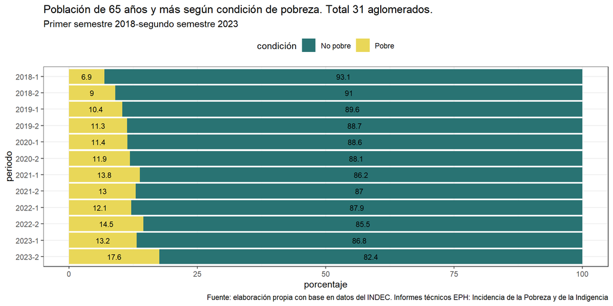

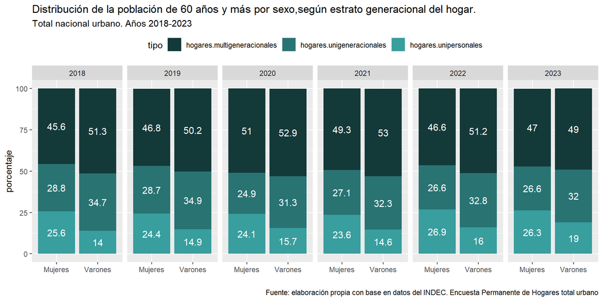

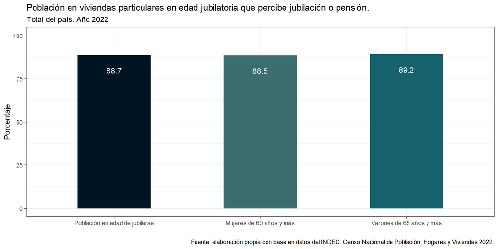

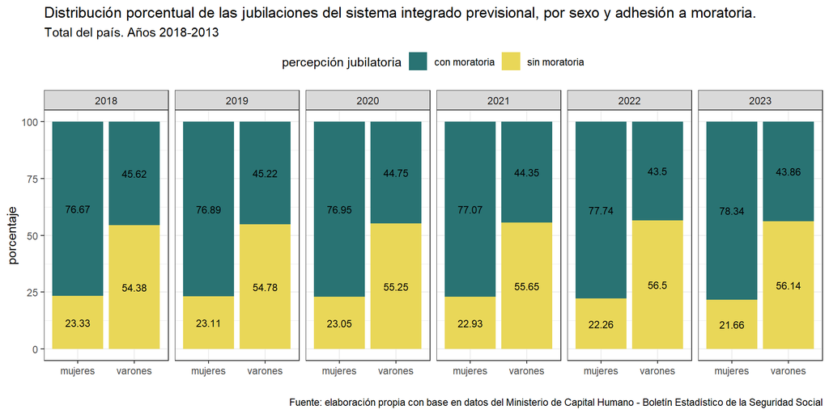

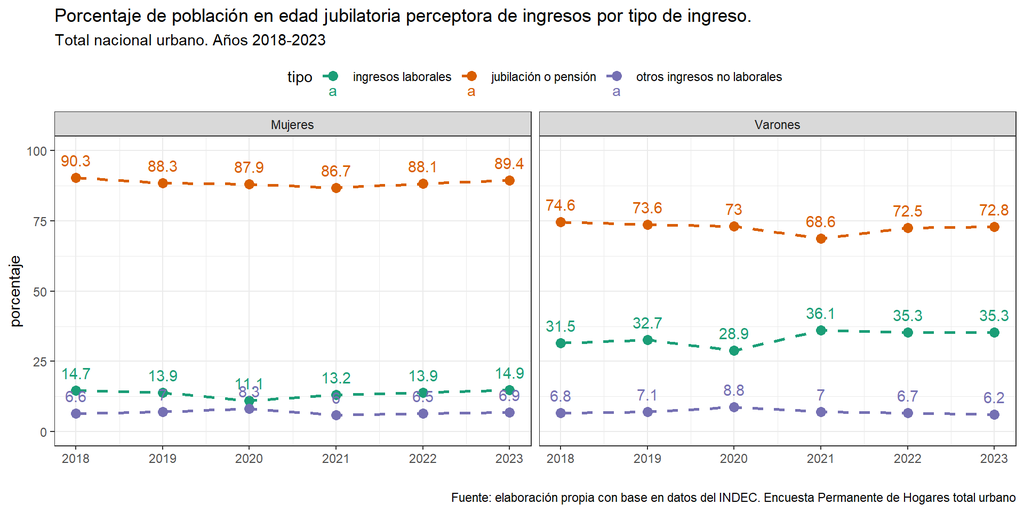

## Fuentes de información

| Organismo | Fuente de información | Período |
| --- | --- | --- |
| INDEC | Censo Nacional de Población, Hogares y Vivienda 2022 | 2022 |
| INDEC | Encuesta Permanente de Hogares (EPH) total urbano. | Años 2018 -2023 |
| INDEC | Encuesta Nacional de Uso del Tiempo (ENUT 2021). | Año 2021 |
| Ministerio de Capital Humano | Boletín Estadístico de la Seguridad Social | Años 2018 - 2023 |